# TP2 - Correction

Traitement des données

INTECHMER - CT2 GEM/PVRM

## Chargement des librairies

Voici les raisons du chargement pour chaque librairie :

- `tidyverse` : pour tout ce qui manipulation de données et création de graphiques ;
- `scales` : pour la fonction `percent` dans le diagramme circulaire ;
- `knitr` : pour afficher un tableau de façon propre ;
- `kableExtra` : pour améliorer l’affichage d’un tableau ;
- `gridExtra` : pour pouvoir utiliser la fonction `grid.arrange()`, qui permet d’intégrer plusieurs graphiques en 1 seul.

```r
library(tidyverse)
library(scales)
library(knitr)
library(kableExtra)
library(gridExtra)
```

## Importation des données

Les données sont donc dans le fichier `DataLIMAT.txt` et les valeurs sont délimitées par une tabulation. Ici, pas besoin de mettre de paramètre à la fonction `read_delim()`.

```r
limat = read_delim("DataLIMAT.txt")
```

|  | ID_SIGHTING | ID_OBSERVER | COLLECTION_MODE | ID_SSU | ID_PSU | DEPARTEMENT | COORD_LON | COORD_LAT | SPECIES_NAME | LATIN_NAME | CD_NOM_TAXREF | VALID_LATIN_NAME | DATE | TIME_START | TIME_STOP | TIMING | ESTIMATION_CODE | TOTAL_COUNT | COUNT_AD_MALE | COUNT_AD_FEMALE | COUNT_ADULT | COUNT_CHICK | COUNT_IMMATURE | COUNT_FLY | ATLAS_CODE |
| --- | --- | --- | --- | --- | --- | --- | --- | --- | --- | --- | --- | --- | --- | --- | --- | --- | --- | --- | --- | --- | --- | --- | --- | --- | --- |
| 1 | 59f29377-8a27-41eb-adf1-041005ffae09 | 2 | App | E09215N67275 | E092N672 | 70 | 5.95551 | 47.611603 | Grive musicienne | Turdus philomelos | 4129 | Turdus philomelos | 2021-03-21 | 2021-03-21T09:51:00Z | 2021-03-21T10:22:00Z | 09:54:00 |  | 2 |  |  | 2 |  |  | 0 | 1 |
| 2 | 59f7127f-8a27-41eb-adf1-041005ffae0a | 2 | App | E09215N67275 | E092N672 | 70 | 5.95547 | 47.6113 | Martin-pêcheur d'Europe | Alcedo atthis | 3571 | Alcedo atthis | 2021-03-21 | 2021-03-21T09:51:00Z | 2021-03-21T10:22:00Z | 09:55:00 |  | 1 |  |  | 1 |  |  | 0 | 1 |
| 3 | 59f9ab2e-8a27-41eb-adf1-041005ffae0b | 2 | App | E09215N67275 | E092N672 | 70 | 5.954654 | 47.611879 | Pinson des arbres | Fringilla coelebs | 4564 | Fringilla coelebs | 2021-03-21 | 2021-03-21T09:51:00Z | 2021-03-21T10:22:00Z | 09:56:00 |  | 1 | 1 | 0 | 1 | 0 | 0 | 0 | 2 |
| 4 | 59fe3f65-8a27-41eb-adf1-041005ffae0c | 2 | App | E09215N67275 | E092N672 | 70 | 5.955084 | 47.611271 | Ouette d'Égypte | Alopochen aegyptiaca | 459626 | Alopochen aegyptiaca | 2021-03-21 | 2021-03-21T09:51:00Z | 2021-03-21T10:22:00Z | 09:57:00 |  | 2 |  |  | 2 |  |  | 0 | 3 |
| 5 | 5a00d2b2-8a27-41eb-adf1-041005ffae0d | 2 | App | E09215N67275 | E092N672 | 70 | 5.954775 | 47.611444 | Rougegorge familier | Erithacus rubecula | 4001 | Erithacus rubecula | 2021-03-21 | 2021-03-21T09:51:00Z | 2021-03-21T10:22:00Z | 09:57:00 |  | 1 | 1 | 0 | 1 | 0 | 0 | 0 | 2 |
| 6 | 5a02e76d-8a27-41eb-adf1-041005ffae0e | 2 | App | E09215N67275 | E092N672 | 70 | 5.955031 | 47.61103 | Rougegorge familier | Erithacus rubecula | 4001 | Erithacus rubecula | 2021-03-21 | 2021-03-21T09:51:00Z | 2021-03-21T10:22:00Z | 09:58:00 |  | 1 | 1 | 0 | 1 | 0 | 0 | 0 | 2 |
| 7 | 5a06bc4d-8a27-41eb-adf1-041005ffae0f | 2 | App | E09215N67275 | E092N672 | 70 | 5.955339 | 47.611049 | Merle noir | Turdus merula | 4117 | Turdus merula | 2021-03-21 | 2021-03-21T09:51:00Z | 2021-03-21T10:22:00Z | 09:59:00 |  | 1 |  |  | 1 |  |  | 0 | 1 |
| 8 | 5a0de9a9-8a27-41eb-adf1-041005ffae10 | 2 | App | E09215N67275 | E092N672 | 70 | 5.955041 | 47.610757 | Milan noir | Milvus migrans | 2840 | Milvus migrans | 2021-03-21 | 2021-03-21T09:51:00Z | 2021-03-21T10:22:00Z | 10:00:00 |  | 2 |  |  | 2 |  |  | 0 | 3 |
| 9 | 5a125e74-8a27-41eb-adf1-041005ffae11 | 2 | App | E09215N67275 | E092N672 | 70 | 5.955126 | 47.610569 | Bergeronnette grise | Motacilla alba | 3941 | Motacilla alba | 2021-03-21 | 2021-03-21T09:51:00Z | 2021-03-21T10:22:00Z | 10:00:00 |  | 1 |  |  | 1 |  |  | 0 | 1 |
| 10 | 5a156266-8a27-41eb-adf1-041005ffae12 | 2 | App | E09215N67275 | E092N672 | 70 | 5.952111 | 47.611618 | Corneille noire | Corvus corone | 4503 | Corvus corone | 2021-03-21 | 2021-03-21T09:51:00Z | 2021-03-21T10:22:00Z | 10:02:00 |  | 5 |  |  | 5 |  |  | 0 | 1 |

[output cut: 90 more lines]

Ecrire un petit texte introductif, en indiquant la source des données

## Indiquer quelques éléments sur ces données

On va créer plusieurs *chuncks* pour avoir toutes les informations. Idéalement, il faudrait les écrire dans une phrase (comme pour la première – regarder le fichier `.Rmd` pour voir comment faire).

### Nombre total d’observation

```r
nrow(limat)
```

```
## [1] 64731
```

On peut aussi le mettre dans une phrase : Il y a 64731 observations dans la base de données.

### Etendue des observations

```r
range(limat$DATE)
```

```
## [1] "2021-03-19" "2022-06-29"
```

### Nombre d’observateurs

```r
n_distinct(limat$ID_OBSERVER)
```

```
## [1] 764
```

### Nombre de départements

```r
n_distinct(limat$DEPARTEMENT)
```

```
## [1] 88
```

### Nombre d’espèces

```r
n_distinct(limat$SPECIES_NAME)
```

```
## [1] 307
```

## Donner le TOP10 des observateurs les plus présents

La fonction `count()` permet donc de calculer le nombre d’occurrences pour chaque modalité de la variable passée en paramètre.

L’observateur le plus *productif* (avec l’identifiant 695) a fait presque 2000 observations.

```r
top10 = limat %>%
  count(ID_OBSERVER) %>%
  arrange(desc(n)) %>%
  head(10)
kable(top10) %>%
  kable_styling(full_width = FALSE)
```

| ID_OBSERVER | n |
| --- | --- |
| 695 | 1971 |
| 222 | 1203 |
| 520 | 1192 |
| 353 | 1069 |
| 177 | 983 |
| 190 | 812 |
| 62 | 788 |
| 510 | 716 |
| 380 | 698 |
| 383 | 632 |

## Représenter le nombre d’observations par observateurs avec une boîte à moustaches

La très grande majorité des observateurs font moins d’une centaine d’observations.

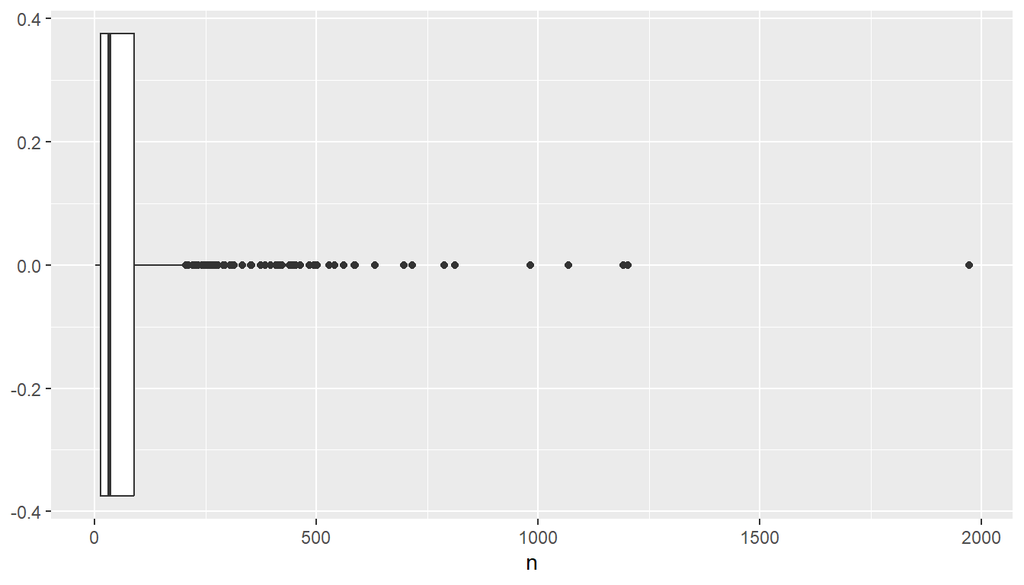

```r
limat %>%
  count(ID_OBSERVER) %>%
  ggplot(aes(x = n)) +
  geom_boxplot()
```

## Représenter sur une carte l’ensemble des observations

La fonction `map_data("france)` (du package `maps` - chargé automatiquement lors de son utilisation) permet de récupérer les polygones représentant la France métropolitaine (la partie continentale et les différentes îles autour - sans les territoires d’Outre-Mer).

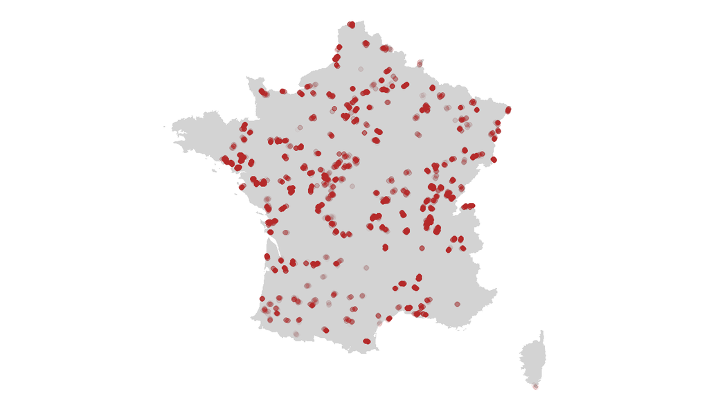

```r
ggplot() +
  geom_polygon(data = map_data("france"), aes(x = long, y = lat, group = group), fill = "lightgray") +
  geom_point(data = limat, aes(COORD_LON, COORD_LAT), color = "red4", alpha = .01) +
  theme_void() +
  coord_map()
```

## Représenter, à l’aide d’un diagramme en barres, le nombre d’observations pour chaque espèce

*Attention* : il est judicieux de trier les espèces par ordre décroissant d’observations dans ce genre de représentations

Ce graphique est malheureusement quelque peu illisible…

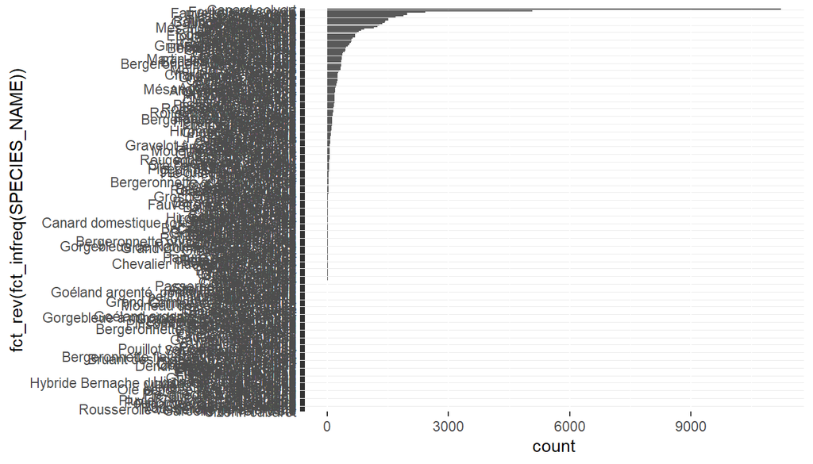

```r
ggplot(limat, aes(y = fct_rev(fct_infreq(SPECIES_NAME)))) +
  geom_bar()
```

On va donc choisir d’afficher les 20 espèces les plus observées.

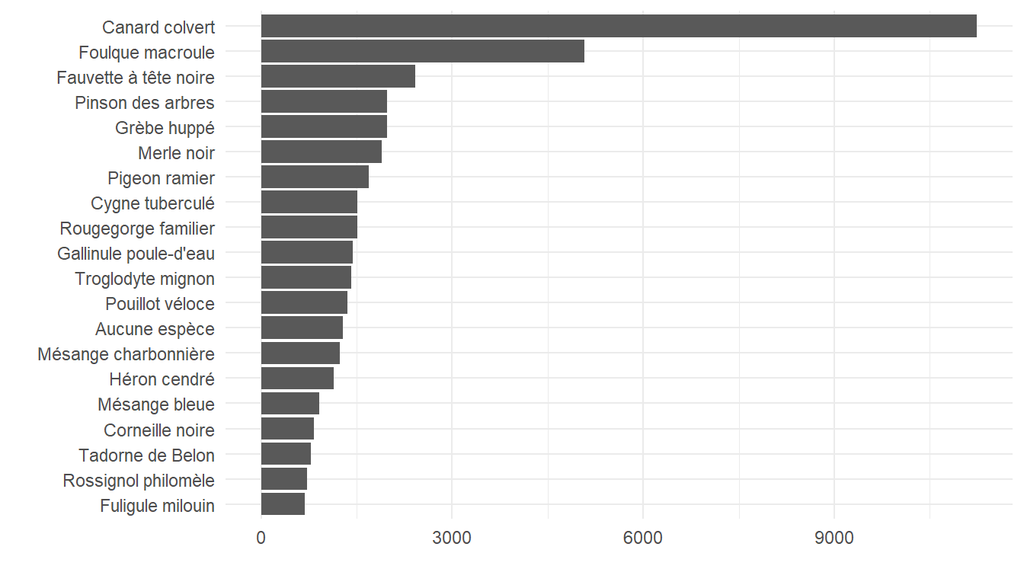

```r
limat %>%
  count(SPECIES_NAME) %>%
  arrange(desc(n)) %>%
  head(20) %>%
  ggplot(aes(y = fct_reorder(SPECIES_NAME, n), x = n)) +
  geom_bar(stat = "identity") +
  theme_minimal() +
  labs(x = "", y = "")
```

## Représenter, à l’aide d’un diagramme circulaire, la part de chaque mode d’observations (collection_mode)

La grande majorité des observations sont faites via une application mobile.

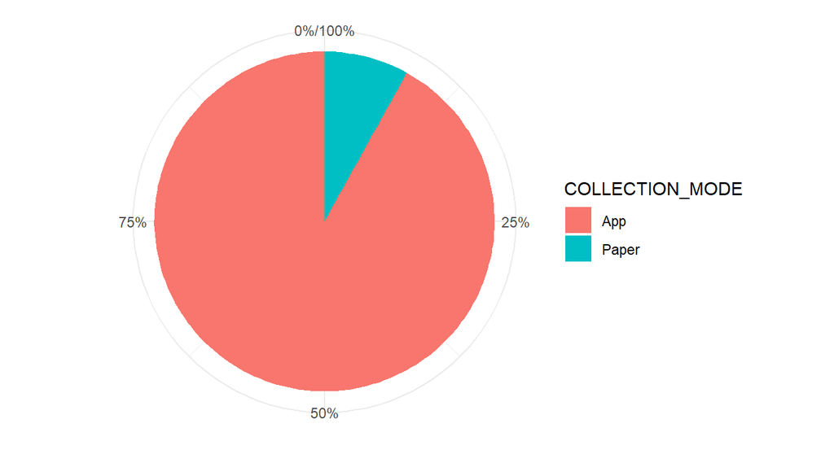

```r
ggplot(limat, aes(x = "", fill = COLLECTION_MODE)) +
  geom_bar(position = "fill") +
  scale_y_continuous(labels = percent) +
  coord_polar(theta = "y") +
  labs(x = "", y = "") +
  theme_minimal()
```

## Représenter le nombre d’oiseaux observés par observations, à l’aide d’un histogramme

La fonction `drop_na()` permet de supprimer les lignes avec données manquantes (valeur `NA` dans R). En indiquant un champs, cela n’enlève que les lignes pour lesquelles une valeur est manquante pour cette variable.

Ici, le graphique nous indique qu’il existe une observation avec un nombre d’oiseaux proche de 500 (490 précisemment).

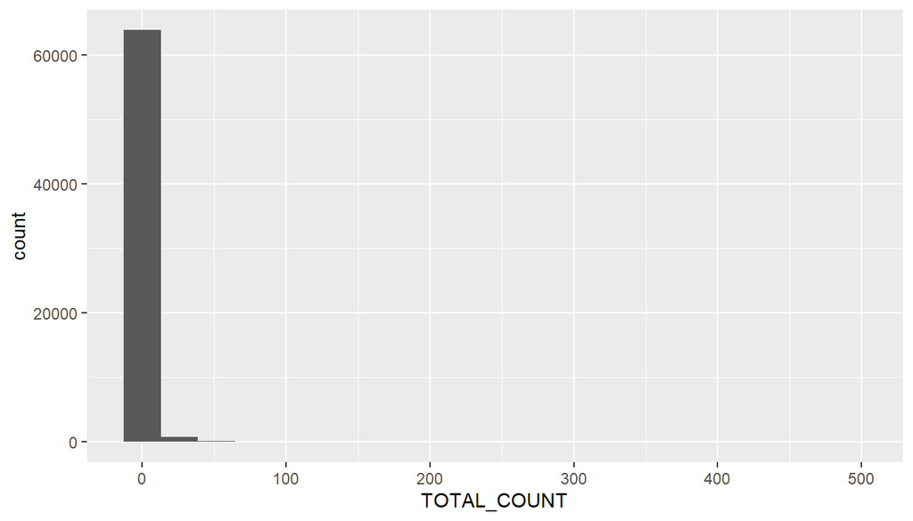

```r
ggplot(limat %>% drop_na(TOTAL_COUNT), aes(x = TOTAL_COUNT)) +
  geom_histogram(bins = 20)
```

## Représenter le nombre d’observations par heure, avec un diagramme en barres

Les observations sont principalement faites le matin, probablement avant d’aller au travail, et parfois le soir, en rentrant.

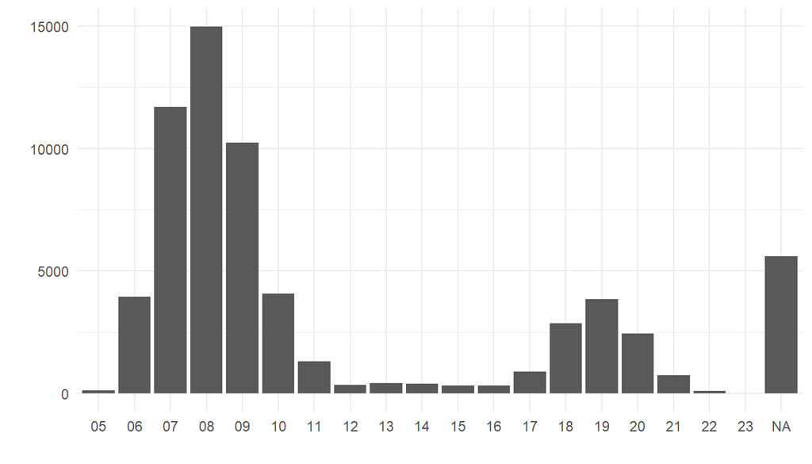

```r
limat %>%
  mutate(heure = str_sub(TIMING, 1, 2)) %>%
  ggplot(aes(heure)) +
  geom_bar() +
  theme_minimal() +
  labs(x = "", y = "")
```

## Représenter, pour chaque département

### le nombre d’observations (diagramme en barres)

Encore une fois, ce graphique n’est pas totalement lisible.

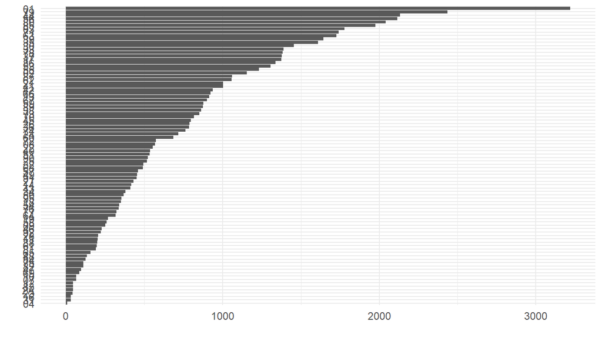

```r
ggplot(limat, aes(y = fct_rev(fct_infreq(DEPARTEMENT)))) +
  geom_bar() +
  theme_minimal() +
  labs(x = "", y = "")
```

On choisit de séparer en deux les départements, en fonction de la médiane.

L’Ain est le département avec le plus d’observations.

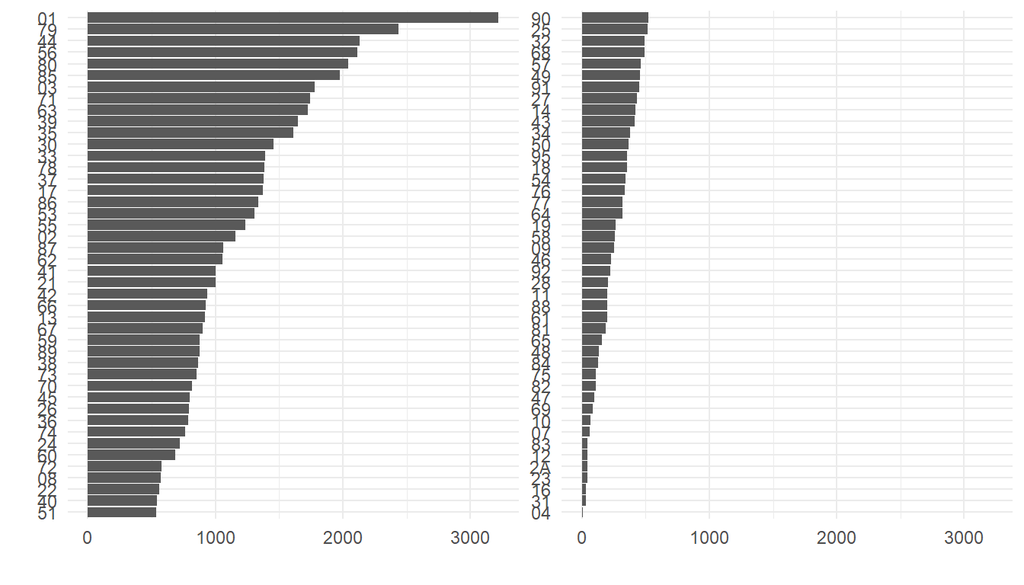

```r
nbobs_par_dpt = limat %>%
  count(DEPARTEMENT)

nbobs_par_dpt = nbobs_par_dpt %>%
  mutate(cote = n < median(nbobs_par_dpt$n))

ggplot(nbobs_par_dpt, aes(y = fct_reorder(DEPARTEMENT, n), x = n)) +
  geom_bar(stat = "identity") +
  theme_minimal() +
  labs(x = "", y = "") +
  facet_wrap(~ cote, scales = "free_y") +
  theme(strip.text = element_blank())
```

### le nombre total d’oiseaux observés (idem)

Même processus que précédemment.

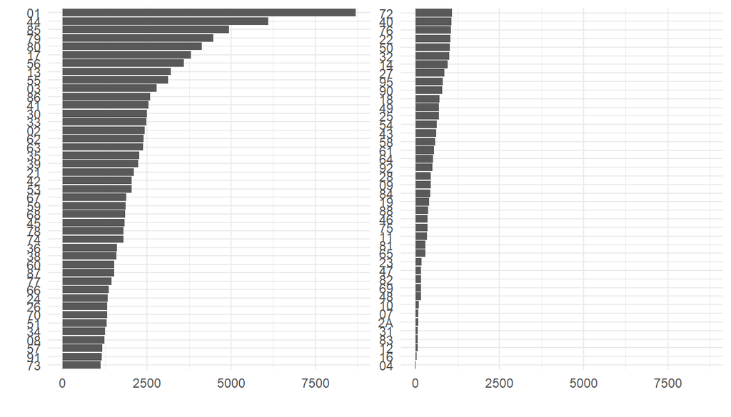

```r
nboiseaux_par_dpt = limat %>%
  group_by(DEPARTEMENT) %>%
  summarise(n = sum(TOTAL_COUNT))
nboiseaux_par_dpt = nboiseaux_par_dpt %>%
  drop_na() %>%
  mutate(cote = n < median(nboiseaux_par_dpt$n, na.rm = TRUE))

ggplot(nboiseaux_par_dpt, aes(y = fct_reorder(DEPARTEMENT, n), x = n)) +
  geom_bar(stat = "identity") +
  theme_minimal() +
  labs(x = "", y = "") +
  facet_wrap(~ cote, scales = "free_y") +
  theme(strip.text = element_blank())
```

### la part de chaque mode d’observations (diagramme en barres empilées)

Il serait un peu plus difficile de faire le même processus qu’avant, on choisit donc de garder celui-ci.

On voit que pour la majorité des départements, ce sont des observations via application. Toutefois, pour deux départements, les observations sont exclusivement via papier.

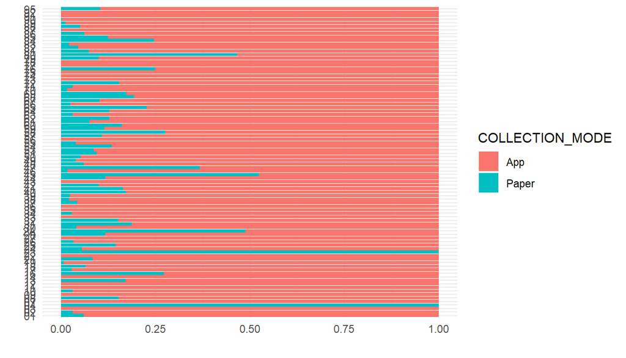

```r
ggplot(limat,
       aes(y = DEPARTEMENT, fill = COLLECTION_MODE)) +
  geom_bar(position = "fill") +
  labs(x = "", y = "") +
  theme_minimal()
```

### Avec une carte plutôt que des diagrammes en barres

On a récupéré les contours des départements (présents dans le fichier **`departements.geojson`** – à télécharger) sur le site https://france-geojson.gregoiredavid.fr/.

#### Affichage de la carte des départements

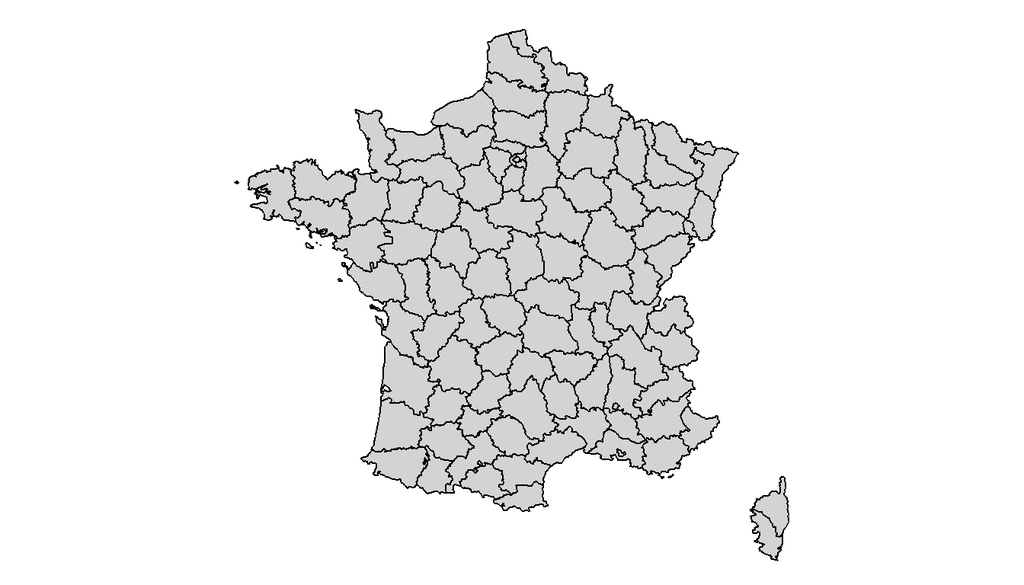

```r
library(geojsonio)
dpt_geo = geojson_read("departements.geojson", what = "sp")

ggplot(fortify(dpt_geo), aes(long, lat, group = group)) +
  geom_polygon(fill = "lightgray", color = "black") +
  theme_void() +
  coord_map()
```

#### Nb d’observations par département

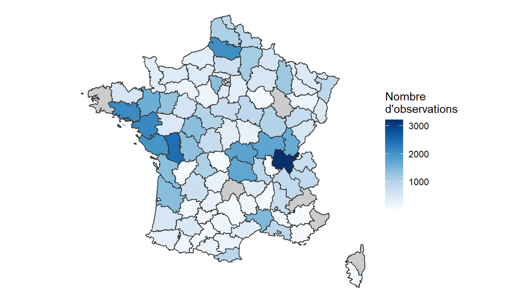

```r
dpt_nbobs = dpt_geo@data %>%
  left_join(limat %>% count(DEPARTEMENT),
            by = join_by(code == DEPARTEMENT)) %>%
  rownames_to_column("id")

dpt_geo_nbobs = dpt_geo %>%
  fortify() %>%
  left_join(dpt_nbobs, by = "id")

ggplot(dpt_geo_nbobs, aes(long, lat, group = group, fill = n)) +
  geom_polygon(color = "grey20") +
  theme_void() +
  scale_fill_continuous(palette = "Blues", na.value = "grey80") +
  labs(fill = "Nombre\nd'observations") +
  coord_map()
```

#### Nb d’oiseaux par département

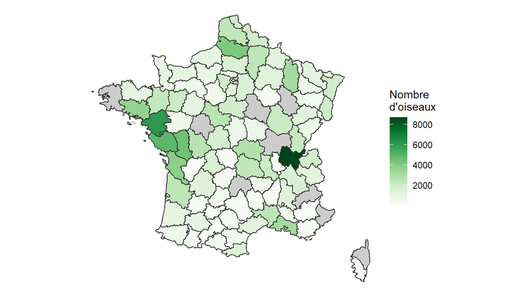

```r
dpt_nboiseaux = dpt_geo@data %>%
  left_join(limat %>%
              group_by(DEPARTEMENT) %>%
              summarise(n = sum(TOTAL_COUNT)),
            by = join_by(code == DEPARTEMENT)) %>%
  rownames_to_column("id")

dpt_geo_nboiseaux = dpt_geo %>%
  fortify() %>%
  left_join(dpt_nboiseaux, by = "id")

ggplot(dpt_geo_nboiseaux, aes(long, lat, group = group, fill = n)) +
  geom_polygon(color = "grey20") +
  theme_void() +
  scale_fill_continuous(palette = "Greens", na.value = "grey80") +
  labs(fill = "Nombre\nd'oiseaux") +
  coord_map()
```

#### Mode de collection

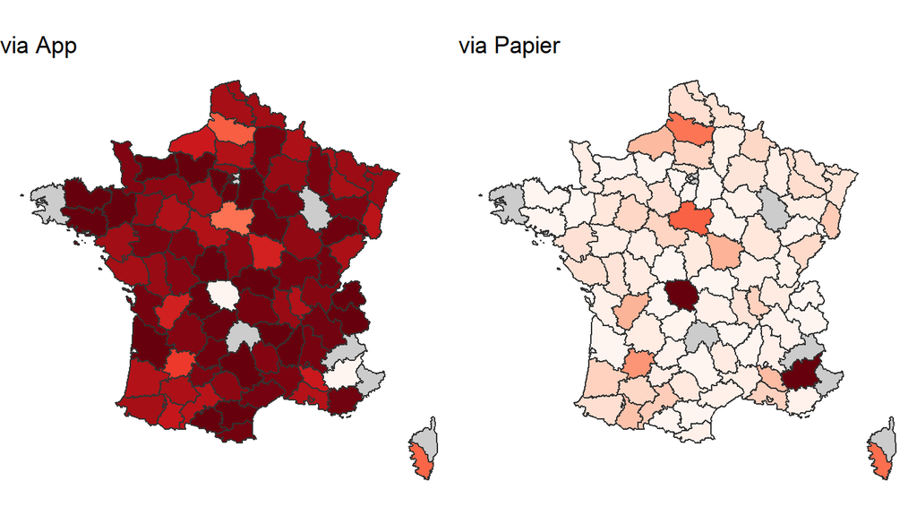

Part de chaque mode d’observations par département (en % - plus c’est rouge, plus c’est proche de 100%)

```r
dpt_mode_freq = limat %>%
  count(DEPARTEMENT, COLLECTION_MODE) %>%
  group_by(DEPARTEMENT) %>%
  mutate(freq = n / sum(n)) %>%
  select(-n) %>%
  pivot_wider(names_from = COLLECTION_MODE, values_from = freq) %>%
  replace(is.na(.), 0)

dpt_mode = dpt_geo@data %>%
  rownames_to_column("id") %>%
  left_join(dpt_mode_freq,
            by = join_by(code == DEPARTEMENT))

dpt_geo_mode = dpt_geo %>%
  fortify() %>%
  left_join(dpt_mode, by = "id")

gApp = ggplot(dpt_geo_mode, aes(long, lat, group = group, fill = App)) +
  geom_polygon(color = "grey20", show.legend = FALSE) +
  theme_void() +
  scale_fill_continuous(palette = "Reds", na.value = "grey80") +
  ggtitle("via App") +
  coord_map()
gPaper = ggplot(dpt_geo_mode, aes(long, lat, group = group, fill = Paper)) +
  geom_polygon(color = "grey20", show.legend = FALSE) +
  theme_void() +
  scale_fill_continuous(palette = "Reds", na.value = "grey80") +
  ggtitle("via Papier") +
  coord_map()
grid.arrange(gApp, gPaper, ncol = 2)
```

## Représenter sur une carte l’ensemble des observations en colorant celle-ci en fonction du mode d’observations

Inutile car nous n’avons pas les coordonnées pour les saisies papier…

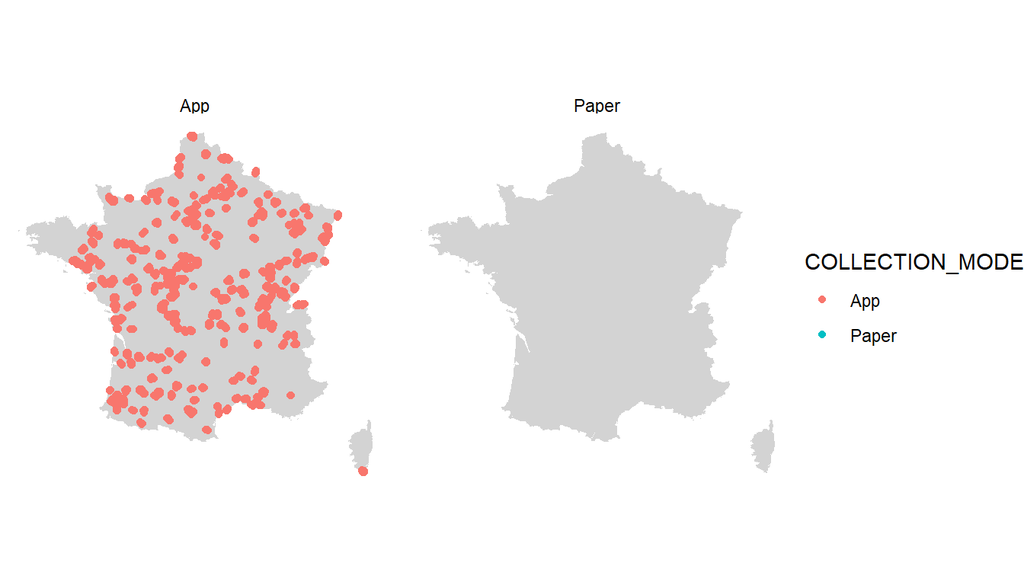

```r
ggplot() +
  geom_polygon(data = map_data("france"), aes(x = long, y = lat, group = group), fill = "lightgray") +
  geom_point(data = limat, aes(COORD_LON, COORD_LAT, color = COLLECTION_MODE)) +
  theme_void() +
  facet_wrap(~ COLLECTION_MODE) +
  coord_map()
```

## Cartes avec leaflet

```r
library(leaflet)
```

On définit ici des options générales pour toutes les cartes (donc un seul changement à faire si on souhaite changer pour toutes les cartes).

```r
optCarte = leafletOptions(minZoom = 5,  maxZoom = 7)
tuiles = "CartoDB.Positron"
```

### Carte de chaque observation

```r
leaflet(limat, options = optCarte) %>%
  addProviderTiles(tuiles) %>%
  addCircles(lng = ~COORD_LON,
             lat = ~COORD_LAT,
             radius = 100,
             fillColor = "#900",
             fillOpacity = .2,
             stroke = FALSE)
```

[interactive chart not shown]

### Carte des départements avec information du nombre d’observations

```r
tab_dpt_nbobs = limat %>%
  count(DEPARTEMENT)

dpt_geo_bis = dpt_geo
dpt_geo_bis@data = dpt_geo_bis@data %>%
  left_join(tab_dpt_nbobs,
             join_by(code == DEPARTEMENT))

pal = colorNumeric("Reds",
                   domain = tab_dpt_nbobs$n)

leaflet(dpt_geo_bis, options = optCarte) %>%
  addProviderTiles(tuiles) %>%
  addPolygons(fillColor = ~pal(n),
              fillOpacity = .8,
              color = "#444",
              weight = 1, opacity = 1) %>%
  addLegend(pal = pal, values = ~n,
            title = "Nombre d'observations")
```

[interactive chart not shown]

### Carte des départements avec information du nombre d’oiseaux

```r
tab_dpt_nboiseaux = limat %>%
  group_by(DEPARTEMENT) %>%
  summarise(n = sum(TOTAL_COUNT, na.rm = TRUE))

dpt_geo_ter = dpt_geo
dpt_geo_ter@data = dpt_geo_ter@data %>%
  left_join(tab_dpt_nboiseaux,
             join_by(code == DEPARTEMENT))

pal = colorNumeric("Reds",
                   domain = tab_dpt_nboiseaux$n)

leaflet(dpt_geo_ter, options = optCarte) %>%
  addProviderTiles(tuiles) %>%
  addPolygons(fillColor = ~pal(n),
              fillOpacity = .8,
              color = "#444",
              weight = 1, opacity = 1) %>%
  addLegend(pal = pal, values = ~n,
            title = "Nombre d'oiseaux")
```

[interactive chart not shown]

### Carte des départements avec mode de collection majoritaire

```r
tab_dpt_mode = dpt_mode_freq %>%
  mutate(mode = ifelse(App > Paper, "App", "Paper"))

dpt_geo_quater = dpt_geo
dpt_geo_quater@data = dpt_geo_quater@data %>%
  left_join(tab_dpt_mode,
             join_by(code == DEPARTEMENT))

pal = colorFactor(palette = c("orange", "steelblue"), domain = unique(tab_dpt_mode$mode) )

leaflet(dpt_geo_quater, options = optCarte) %>%
  addProviderTiles(tuiles) %>%
  addPolygons(fillColor = ~pal(mode),
              fillOpacity = .8,
              color = "#444",
              weight = 1, opacity = 1) %>%
  addLegend(pal = pal, values = ~mode,
            title = "Mode de collecte\n majoritaire")
```

[interactive chart not shown]